# Practical Machine Learning Project

Shawn Kercher

March 20, 2016

### Summary

Using devices such as Jawbone Up, Nike FuelBand, and Fitbit it is now possible to collect a large amount of data about personal activity relatively inexpensively. These type of devices are part of the quantified self movement – a group of enthusiasts who take measurements about themselves regularly to improve their health, to find patterns in their behavior, or because they are tech geeks. One thing that people regularly do is quantify how much of a particular activity they do, but they rarely quantify how well they do it. In this project, your goal will be to use data from accelerometers on the belt, forearm, arm, and dumbell of 6 participants. They were asked to perform barbell lifts correctly and incorrectly in 5 different ways. More information is available from the website here: http://groupware.les.inf.puc-rio.br/har (see the section on the Weight Lifting Exercise Dataset).

#### Load Libraries

```r
library(caret)
library(rpart)
library(rpart.plot)
library(RColorBrewer)
library(rattle)
library(randomForest)
library(RGtk2)
```

#### Read the download and read the data

```r
#Setting seed for reproducing same data
set.seed(15)

training <-read.csv("https://d396qusza40orc.cloudfront.net/predmachlearn/pml-training.csv", na.strings=c("NA","#DIV/0!",""))
testing <-read.csv("https://d396qusza40orc.cloudfront.net/predmachlearn/pml-testing.csv", na.strings=c("NA","#DIV/0!",""))
```

#### Clean the Data

Deleting columns with missing values and removing variables that will not be used

```r
training <- training [,colSums(is.na(training)) == 0]
testing <- testing [,colSums(is.na(testing)) == 0]

training <- training[,-c(1:7)]
testing <- testing[,-c(1:7)]
```

Partition the data into two sets. Training and testing

```r
train1 <- createDataPartition(y=training$classe, p=0.6, list=FALSE)
mTraining <- training[train1, ]; myTesting <- training[-train1, ]
dim(mTraining); dim(myTesting)
```

```
## [1] 11776    53
```

```
## [1] 7846   53
```

#### Descision Tree

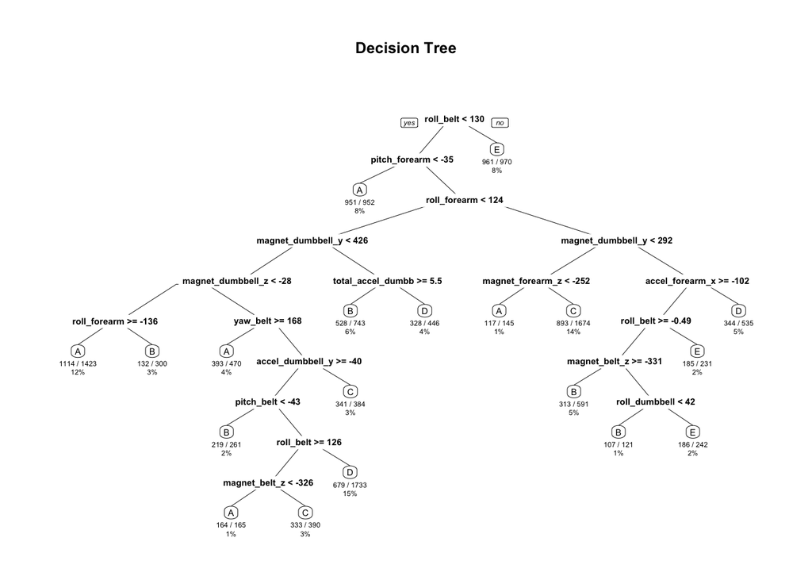

```r
model1 <- rpart(classe ~ ., data=mTraining, method="class")
prediction1 <- predict(model1, myTesting, type = "class")
rpart.plot(model1, main="Decision Tree", extra=102, under=TRUE, faclen=0)
```

```r
confusionMatrix(prediction1, myTesting$classe)
```

```
## Confusion Matrix and Statistics
##
##           Reference
## Prediction    A    B    C    D    E
##          A 1798  190   13   45   12
##          B   88  862  156  111  149
##          C   71  184 1027  198  161
##          D  254  271  169  892  235
##          E   21   11    3   40  885
##
## Overall Statistics
##
##                Accuracy : 0.6964
##                  95% CI : (0.6861, 0.7066)
##     No Information Rate : 0.2845
##     P-Value [Acc > NIR] : < 2.2e-16
##
##                   Kappa : 0.618
##  Mcnemar's Test P-Value : < 2.2e-16
##
## Statistics by Class:
##
##                      Class: A Class: B Class: C Class: D Class: E
## Sensitivity            0.8056   0.5679   0.7507   0.6936   0.6137
## Specificity            0.9537   0.9204   0.9052   0.8584   0.9883
## Pos Pred Value         0.8737   0.6310   0.6258   0.4898   0.9219
## Neg Pred Value         0.9250   0.8988   0.9450   0.9346   0.9191
## Prevalence             0.2845   0.1935   0.1744   0.1639   0.1838
## Detection Rate         0.2292   0.1099   0.1309   0.1137   0.1128
## Detection Prevalence   0.2623   0.1741   0.2092   0.2321   0.1224
## Balanced Accuracy      0.8796   0.7441   0.8280   0.7760   0.8010
```

#### Random Forest

```r
model2 <- randomForest(classe ~. , data=mTraining, method="class")
prediction2 <- predict(model2, myTesting, type = "class")
confusionMatrix(prediction2, myTesting$classe)
```

```
## Confusion Matrix and Statistics
##
##           Reference
## Prediction    A    B    C    D    E
##          A 2228    6    0    0    0
##          B    4 1507   11    0    0
##          C    0    5 1356   19    0
##          D    0    0    1 1267    6
##          E    0    0    0    0 1436
##
## Overall Statistics
##
##                Accuracy : 0.9934
##                  95% CI : (0.9913, 0.995)
##     No Information Rate : 0.2845
##     P-Value [Acc > NIR] : < 2.2e-16
##
##                   Kappa : 0.9916
##  Mcnemar's Test P-Value : NA
##
## Statistics by Class:
##
##                      Class: A Class: B Class: C Class: D Class: E
## Sensitivity            0.9982   0.9928   0.9912   0.9852   0.9958
## Specificity            0.9989   0.9976   0.9963   0.9989   1.0000
## Pos Pred Value         0.9973   0.9901   0.9826   0.9945   1.0000
## Neg Pred Value         0.9993   0.9983   0.9981   0.9971   0.9991
## Prevalence             0.2845   0.1935   0.1744   0.1639   0.1838
## Detection Rate         0.2840   0.1921   0.1728   0.1615   0.1830
## Detection Prevalence   0.2847   0.1940   0.1759   0.1624   0.1830
## Balanced Accuracy      0.9986   0.9952   0.9938   0.9921   0.9979
```

#### Correlation

```r
corr <- caret::findCorrelation(cor(mTraining[, -53]), cutoff=0.8)
names(mTraining)[corr]
```

```
##  [1] "accel_belt_z"     "roll_belt"        "accel_belt_y"
##  [4] "accel_dumbbell_z" "accel_belt_x"     "pitch_belt"
##  [7] "accel_dumbbell_x" "accel_arm_x"      "magnet_arm_y"
## [10] "gyros_forearm_y"  "gyros_dumbbell_x" "gyros_dumbbell_z"
## [13] "gyros_arm_x"
```

## Answer Submission Files

```r
submission = function(x){
  n = length(x)
  for(i in 1:n){
    filename = paste0("problem_id_",i,".txt")
    write.table(x[i],file=filename,quote=FALSE,row.names=FALSE,col.names=FALSE)
  }
}

submission(prediction1)
```